## 計量地理學及實習 期中考二參考答案

#### 助教 杜承軒 2018.12.01

### Part A:Ripley’s K function的觀念與計算 (共30%)

> $d=100時，$  
> $右上方的點(1個)環域會包含0個鄰居，$  
> $中間區域的點(6個)環域會包含5個鄰居，$  
> $下方點(2個)環域會包含1個鄰居。$  
> $因此，點的個數：9個，$  
> $加總點的數量=0+5+5+5+5+5+5+1+1=32$  
> $研究區面積=250*250=62500$  
> $K(d)=平均鄰居\div點密度=\frac{32}{9} \div \frac{9}{62500}\approx24691$  
> $L(d)=\sqrt{\frac{K(d)}{\pi}}-d=\sqrt{\frac{24691}{\pi}}-100\approx-11.35$

> 用程式實作方法

> ```r
> pt=SpatialPoints(cbind(c(100,100,125,125,137.5,137.5,150,150,250),c(0,150,150,125,137.5,112.5,0,150,250)))
> dist=gDistance(pt,pt,byid=T)
> count=sum(dist<100)-9
> K_100=count/9*250*250/9
> L_100=sqrt(K_100/pi)-100
> cat("K(100)=",K_100,"; L(100)=",L_100)
> ```

> ```
> ## K(100)= 24691.36 ; L(100)= -11.34616
> ```

### Part B：實作題 (警力資源佈署計畫) (共70%)

> > 由於近年恐怖活動地點都集中在全球的主要都市，台北市政府決定要擬定「台北市恐怖攻擊應變計劃」的標準作業程序。因情報顯示，恐怖攻擊通常都會鎖定人潮眾多的交通或商業機構，台北市政府挑出了台北101(TP101.shp)，作為假想的恐怖攻擊目標，並且針對犯罪資料(crime.shp)進行空間分析，以利後續的警力資源(PoliceStation.shp)的佈署與規劃。假設你是台北市政府的幕僚人員，請協助以下的分析。

> ```r
> library(GISTools);library(rgdal);library(sp);library(aspace);library(spatstat)
> setwd("D:/1071QG/Mid2")
> Crime=readOGR(dsn = "Data", layer = "Crime", encoding="utf8")
> TP101=readOGR(dsn = "Data", layer = "TP101", encoding="utf8")
> Police=readOGR(dsn = "Data", layer = "PoliceStation", encoding="utf8")
> TP=readOGR(dsn = "Data", layer = "Taipei", encoding="utf8")
> ```

> > 1. [10%] 市政府想要比較北市犯罪地點和警力資源的空間分布，請繪製Standard Deviational Ellipse進行空間分布的描述與比較。

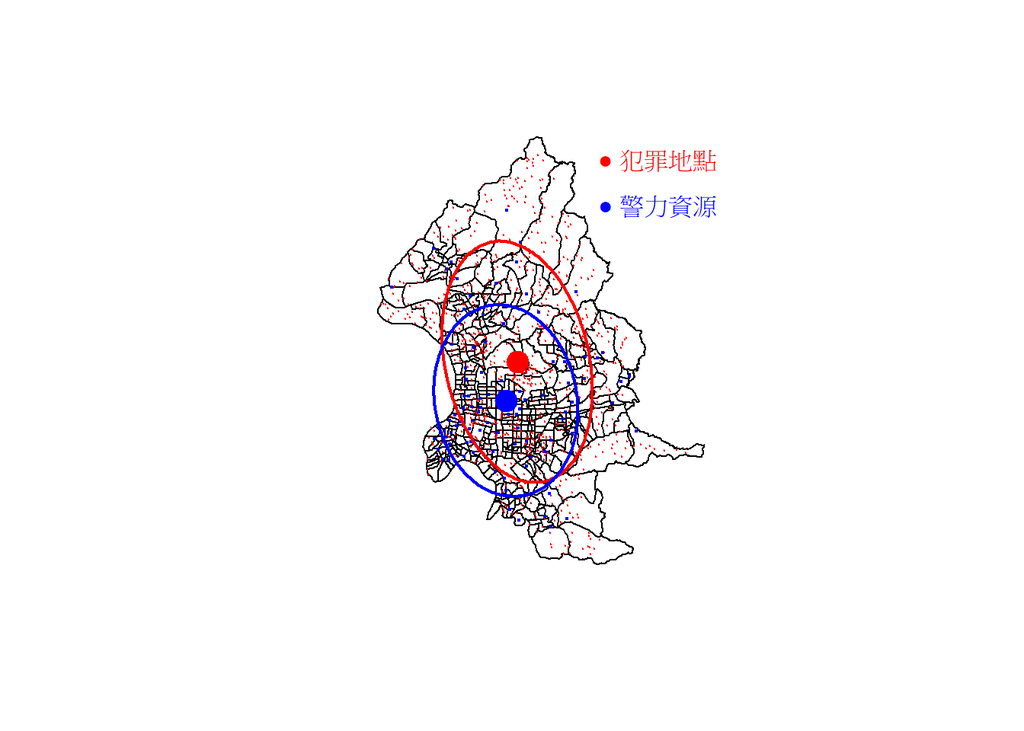

> ```r
> plot(TP)
> points(Crime,cex=0.2,pch=20,col='red')
> points(Police,cex=0.4,pch=20,col='blue')
> Crime.pt=cbind(Crime@coords[,1],Crime@coords[,2])
> Police.pt=cbind(Police@coords[,1],Police@coords[,2])
> calc_sde(points=Crime.pt)
> plot_sde(plotnew=F, plotcentre=T, titletxt="",cex=2,plotpoints=F,sde.col="red",centre.col="red")
> calc_sde(points=Police.pt)
> plot_sde(plotnew=F, plotcentre=T, titletxt="",cex=2,plotpoints=F,sde.col="blue",centre.col="blue")
> text(315000,2787500,"● 犯罪地點",cex=0.5,col="red")
> text(315000,2784500,"● 警力資源",cex=0.5,col="blue")
> ```

> > 2. 市政府定義台北101方圓1公里內為潛在危險區，並想要進一步探討犯罪事件在潛在危險區中的分布狀況。需進行以下的分析：  
> >    (a) [20%] 建立100公尺x 100公尺的均勻網格，利用Quadrat Analysis的方法，在95%信心水準下，檢定潛在危險區中的犯罪地點是否為群聚的型態。若潛在危險區中有犯罪群聚現象，可進行更深入的犯罪偵查調查與投入更多的警力資源。

> ```r
> Buf101=gBuffer(TP101,width = 1000)
> grd=GridTopology(c(TP101@coords[1,1]-950,TP101@coords[1,2]-950),c(100,100),c(20,20))
> grd=as.SpatialPolygons.GridTopology(grd,proj4string =TP@proj4string)
> CR101=gIntersection(Buf101,Crime)
>
> #Intersect法
> #Inter=gIntersection(grd,Buf101,byid = T)
> #InterName=strsplit(names(Inter)," ")
> #Pix=lapply(InterName,function(x) substring(x[1],2))
> #Pix=as.numeric(unlist(Pix))
> #grd=grd[Pix,]
>
> #Distance法
> pix=c()
> for(i in 1:400){if(gDistance(grd[i,],Buf101)==0) pix=c(pix,i)}
> grd=grd[pix,]
>
> num=poly.counts(Crime,grd)
> S.m=mean(num);S.v=var(num)
> S.vmr=S.v/S.m
> S.se=sqrt(2/(length(grd)-1))
> S.t=(S.vmr-1)/S.se
> pt(S.t,length(grd)-1)
> ```

> ```
> ## [1] 0.325781
> ```

> $虛無假設 H_{0}:s^2\leq\lambda，空間分布是隨機（或均勻）的情況$  
> $對立假設 H_{1}:s^2>\lambda，空間分布是群聚分布的情況$  
> $在顯著水準\alpha=0.05下，p-vaule > \alpha，表示無法拒絕假設檢定$  
> $因此認定這個潛在危險區內的犯罪點不是群聚分布$

> > (b) [20%] 市府長官建議改以第三鄰近距離作為空間鄰近的定義，並利用G function進行分析，在99%信心水準下，檢定潛在危險區中的犯罪地點是否為群聚的型態。

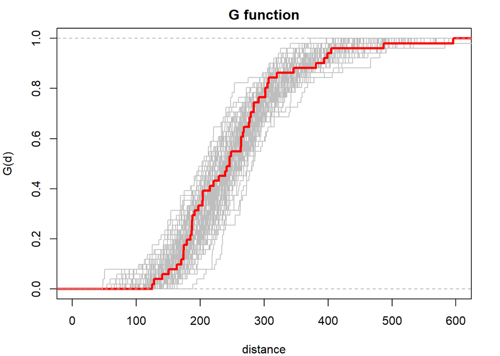

> ```r
> par(mar=c(4,4,2,2),cex=1)
> CR101.ppp=ppp(CR101@coords[,1],CR101@coords[,2],as.owin(Buf101))
> ND=nndist(CR101.ppp,k=3)
> plot(ecdf(ND),verticals = T,lwd=3,cex=0,col="red",main="G function",xlab="distance",ylab="G(d)",xlim=c(0,600))
> for(i in 1:100) {lines(ecdf(nndist(rpoint(length(CR101),win=as.owin(Buf101)),k=3)),col="grey",cex=0,verticals = T)}
> lines(ecdf(ND),verticals = T,lwd=3,cex=0,col="red")
> ```

> 進行100次模擬，事件落在包絡區間之內  
> 因此在99%信心水準下，無法拒絕假設檢定，因此潛在危險區內的犯罪點不是群聚分布
> > 3. [20%] 警力設施(PoliceStation.shp)包括：分局與派出所。利用F function分析，分別評估犯罪地點是否群聚於分局？或群聚於派出所？並針對其分析結果，進行解釋與說明。

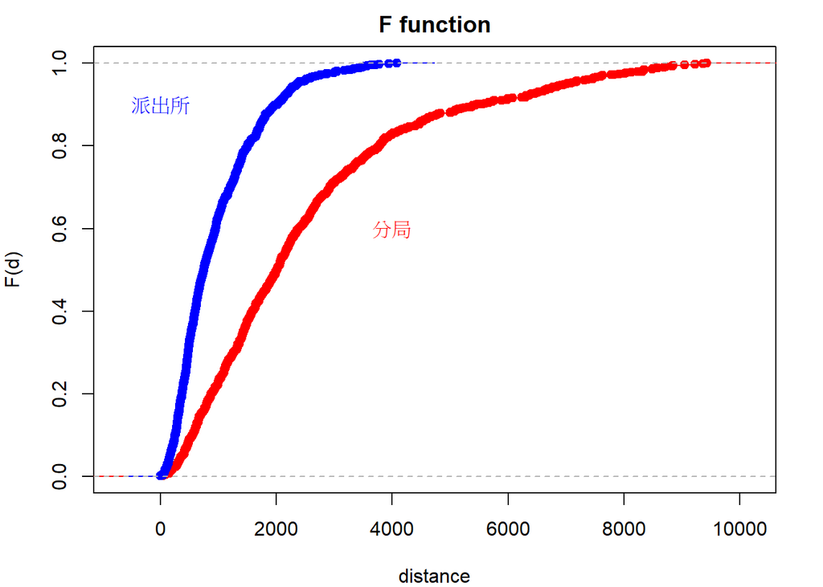

> ```r
> par(mar=c(4,4,2,2),cex=1)
> Right2=function(s) substring(s,nchar(s)-1)
> Police$TYPE=Right2(as.vector(Police$單位))
> Div=subset(Police,Police$TYPE=="分局")
> Sta=subset(Police,Police$TYPE=="出所")
> Crime.p=ppp(Crime@coords[,1],Crime@coords[,2],as.owin(TP))
> Div.p=ppp(Div@coords[,1],Div@coords[,2],as.owin(TP))
> Sta.p=ppp(Sta@coords[,1],Sta@coords[,2],as.owin(TP))
> CD=nncross(Crime.p,Div.p)
> F_CD=ecdf(CD[,1])
> CS=nncross(Crime.p,Sta.p)
> F_CS=ecdf(CS[,1])
> plot(F_CD,col="red",main="F function",xlab="distance",ylab="F(d)")
> plot(F_CS,col="blue",add=T)
> text(0,0.9,"派出所",col="blue")
> text(4000,0.6,"分局",col="red")
> ```

> 犯罪與派出所的關係，比犯罪與分局的關係更有群聚的現象。約六成的犯罪點在派出所一公里以內的範圍，九成在派出所兩公里內的範圍。相較之下，犯罪與分局之間的空間分布的群聚性就沒有這麼密切。